# A Classification Model for the Quality of Dumbbell Exercises

Len Mills

April 25, 2015

## Abstract

Participants were asked to perform one set of 10 repetitions of the Unilateral Dumbbell Biceps Curl in five different fashions: exactly according to the specification (Class A), throwing the elbows to the front (Class B), lifting the dumbbell only halfway (Class C), lowering the dumbbell only halfway (Class D) and throwing the hips to the front (Class E). Class A corresponds to the specified execution of the exercise, while the other 4 classes correspond to common mistakes.

I tested five machine learning algorithms: Recursive Partitioning (rpart), Bagging (treebag), Random Forest (rf) Gradient Boosting (gbm), Quadratic Discriminant Analysis (qda). I used the Accuracy and Kappa measures to evaluate each predictive model. Based on these results, I selected the Random Forest model although the Tree Bagging and Gradient Boosting produced accurate test results as well. The Recursive Partition and Quadratic Discriminant models were not as accurate.

Cross-validation results were calculated and show that 99% out-of-sample accuracy is to be expected weh the sample size is 20 as in the submission test data set.

# Setup of Packages and Functions

```r
library(caret)
library(randomForest)
library(plyr)

#function to write answer files
pml_write_files = function(x){
  n = length(x)
  for(i in 1:n){
    filename = paste0("problem_id_",i,".txt")
    write.table(x[i],file=filename,quote=FALSE,row.names=FALSE,col.names=FALSE)
  }
}
```

# Data Preparation and Partitioning

The data for this project has been generously provided from this [source](http://groupware.les.inf.puc-rio.br/har). I restricted the predictor features used in building the model to only those with no missing observations in the submission test data set. I partitioned the pml.training.csv into 60% train and 40% test data sets. The train data set is used to build the model, and the test data set is used to evaluate the predictive performance of the alternative models.

```r
pml.testing <- read.csv("pml-testing.csv")
obs <- colSums(!is.na(pml.testing))
pml.testing <- pml.testing[,obs==20]
var_names <- colnames(pml.testing)
var_names <- var_names[-c(1,2,3,4,5,6,7,60)]

training <- read.csv("pml-training.csv")

set.seed(32323)
sample <- createDataPartition(y=training$classe,p=0.60,list=FALSE)
train <- training[sample,]
dim(train)
```

```
## [1] 11776   160
```

```r
predictors_train <- train[,colnames(train) %in% var_names]
dim(predictors_train)
```

```
## [1] 11776    52
```

```r
test <- training[-sample,]
dim(test)
```

```
## [1] 7846  160
```

```r
predictors_test <- test[,colnames(test) %in% var_names]
dim(predictors_test)
```

```
## [1] 7846   52
```

# Alternative Machine Learning Algorithms

I tested five machine learning algorithms:

1. Recursive Partitioning (rpart)
2. Bagging (treebag)
3. Random Forest (rf)
4. Gradient Boosting (gbm)
5. Quadratic Discriminant Analysis (qda)

For each algorithm, I examined the predictive performance of the model by generating the confusion matrix and accuracy measures on the hold-out test partition from pml.training.csv file. Each algorithm is presented in the next subsections of this report. For completeness, the confusion matrix and is also tabulated for the train data set, but these matrices are not used to select the final model.

## Recursive Partitioning (rpart)

```r
model.rpart <- train(train$classe ~ .,method='rpart',data=predictors_train)
prediction_train <- predict(model.rpart,predictors_train)
cfm_train_rpart <- confusionMatrix(train$classe,prediction_train)
cfm_train_rpart$table
```

```
##           Reference
## Prediction    A    B    C    D    E
##          A 2146  348  618  224   12
##          B  411 1306  461  101    0
##          C   57   95 1633  269    0
##          D  100  288 1028  514    0
##          E   33  522  495  127  988
```

```r
# using test data set
prediction_test <- predict(model.rpart,predictors_test)
cfm_test_rpart <- confusionMatrix(test$classe,prediction_test)
cfm_test_rpart$table
```

```
##           Reference
## Prediction    A    B    C    D    E
##          A 1395  216  474  145    2
##          B  277  825  341   75    0
##          C   41   59 1089  179    0
##          D   87  177  672  350    0
##          E   21  351  356   71  643
```

```r
round(100*cfm_test_rpart$overall,2)
```

```
##       Accuracy          Kappa  AccuracyLower  AccuracyUpper   AccuracyNull
##          54.83          43.29          53.72          55.94          37.37
## AccuracyPValue  McnemarPValue
##           0.00           0.00
```

## Bagging (treebag)

```r
#treebag
model.tb <- train(train$classe ~ .,method='treebag',data=predictors_train)
prediction_train <- predict(model.tb,predictors_train)
cfm_train_tb <- confusionMatrix(train$classe,prediction_train)
cfm_train_tb$table
```

```
##           Reference
## Prediction    A    B    C    D    E
##          A 3348    0    0    0    0
##          B    0 2278    1    0    0
##          C    0    0 2053    1    0
##          D    0    0    0 1930    0
##          E    0    0    1    0 2164
```

```r
# using test data set
prediction_test <- predict(model.tb,predictors_test)
cfm_test_tb <- confusionMatrix(test$classe,prediction_test)
cfm_test_tb$table
```

```
##           Reference
## Prediction    A    B    C    D    E
##          A 2220    6    5    0    1
##          B   20 1488    8    2    0
##          C    0    8 1354    5    1
##          D    0    3   24 1259    0
##          E    1    2    7    8 1424
```

```r
round(100*cfm_test_tb$overall,2)
```

```
##       Accuracy          Kappa  AccuracyLower  AccuracyUpper   AccuracyNull
##          98.71          98.37          98.44          98.95          28.56
## AccuracyPValue  McnemarPValue
##           0.00            NaN
```

## Random Forest (rf)

```r
model.rf <- randomForest(train$classe ~ ., data=predictors_train, importance=TRUE,proximity=TRUE)
prediction_train <- predict(model.rf,predictors_train)
cfm_train_rf <- confusionMatrix(train$classe,prediction_train)
cfm_train_rf$table
```

```
##           Reference
## Prediction    A    B    C    D    E
##          A 3348    0    0    0    0
##          B    0 2279    0    0    0
##          C    0    0 2054    0    0
##          D    0    0    0 1930    0
##          E    0    0    0    0 2165
```

```r
# using test data set
prediction_test <- predict(model.rf,predictors_test)
cfm_test_rf <- confusionMatrix(test$classe,prediction_test)
cfm_test_rf$table
```

```
##           Reference
## Prediction    A    B    C    D    E
##          A 2229    3    0    0    0
##          B   15 1499    4    0    0
##          C    0   14 1354    0    0
##          D    0    0   17 1269    0
##          E    0    0    5    5 1432
```

```r
round(100*cfm_test_rf$overall,2)
```

```
##       Accuracy          Kappa  AccuracyLower  AccuracyUpper   AccuracyNull
##          99.20          98.98          98.97          99.38          28.60
## AccuracyPValue  McnemarPValue
##           0.00            NaN
```

## Gradient Boosting (gbm)

```r
model.gbm <- train(train$classe ~ .,method='gbm',data=predictors_train,verbose=FALSE)
prediction_train <- predict(model.gbm,predictors_train)
cfm_train_gbm <- confusionMatrix(train$classe,prediction_train)
cfm_train_gbm$table
```

```
##           Reference
## Prediction    A    B    C    D    E
##          A 3316   22    7    2    1
##          B   51 2184   40    3    1
##          C    0   36 1989   26    3
##          D    0    9   48 1864    9
##          E    2   14   11   22 2116
```

```r
# using test data set
prediction_test <- predict(model.gbm,predictors_test)
cfm_test_gbm <- confusionMatrix(test$classe,prediction_test)
cfm_test_gbm$table
```

```
##           Reference
## Prediction    A    B    C    D    E
##          A 2186   21   16    9    0
##          B   57 1406   52    2    1
##          C    0   33 1321   12    2
##          D    5   12   35 1227    7
##          E    3   22   16   20 1381
```

```r
round(100*cfm_test_gbm$overall,2)
```

```
##       Accuracy          Kappa  AccuracyLower  AccuracyUpper   AccuracyNull
##          95.86          94.76          95.39          96.29          28.69
## AccuracyPValue  McnemarPValue
##           0.00           0.00
```

## Quadratic Discriminant Analysis (qda)

```r
model.qda <- train(train$classe ~ .,method='qda',data=predictors_train)
prediction_train <- predict(model.qda,predictors_train)
cfm_train_qda <- confusionMatrix(train$classe,prediction_train)
cfm_train_qda$table
```

```
##           Reference
## Prediction    A    B    C    D    E
##          A 3099  140   54   48    7
##          B  105 1936  216    7   15
##          C    0   91 1948    9    6
##          D    1   13  256 1645   15
##          E    1   62   90   58 1954
```

```r
# using test data set
prediction_test <- predict(model.qda,predictors_test)
cfm_test_qda <- confusionMatrix(test$classe,prediction_test)
cfm_test_qda$table
```

```
##           Reference
## Prediction    A    B    C    D    E
##          A 2024   99   54   48    7
##          B   77 1266  147    9   19
##          C    0   69 1288    4    7
##          D    4    5  183 1075   19
##          E    0   49   53   31 1309
```

```r
round(100*cfm_test_qda$overall,2)
```

```
##       Accuracy          Kappa  AccuracyLower  AccuracyUpper   AccuracyNull
##          88.73          85.78          88.01          89.42          26.83
## AccuracyPValue  McnemarPValue
##           0.00           0.00
```

# Comparing Prediction Accuracies

I used the Accuracy and Kappa statistics from the test data set to select the model to be used in the submission.

```r
results <- rbind(round(100*cfm_test_rpart$overall,2),
                 round(100*cfm_test_rf$overall,2),
                 round(100*cfm_test_tb$overall,2),
                 round(100*cfm_test_gbm$overall,2),
                 round(100*cfm_test_qda$overall,2))
rownames(results) <- c("recursive partition","random forest",
                       "tree bagging","gradient boosting","quadratic discriminant")
results
```

```
##                        Accuracy Kappa AccuracyLower AccuracyUpper
## recursive partition       54.83 43.29         53.72         55.94
## random forest             99.20 98.98         98.97         99.38
## tree bagging              98.71 98.37         98.44         98.95
## gradient boosting         95.86 94.76         95.39         96.29
## quadratic discriminant    88.73 85.78         88.01         89.42
##                        AccuracyNull AccuracyPValue McnemarPValue
## recursive partition           37.37              0             0
## random forest                 28.60              0           NaN
## tree bagging                  28.56              0           NaN
## gradient boosting             28.69              0             0
## quadratic discriminant        26.83              0             0
```

```r
selectedModel <- model.rf  # selected model is set here
```

Based on the results from the hold-out test data set, I selected the Random Forest model although the Tree Bagging and Gradient Boosting produced accurate test results as well. The Recursive Partition and Quadratic Discriminant models were not as accurate.

# Relative Importance of Variables

I examined the relative importance of the variables and did a spot check on the most important variable, which was the roll-belt. As can be seen, the median of the roll_belt is substantially lower for classe A (correct performance) compared to the other four classes.

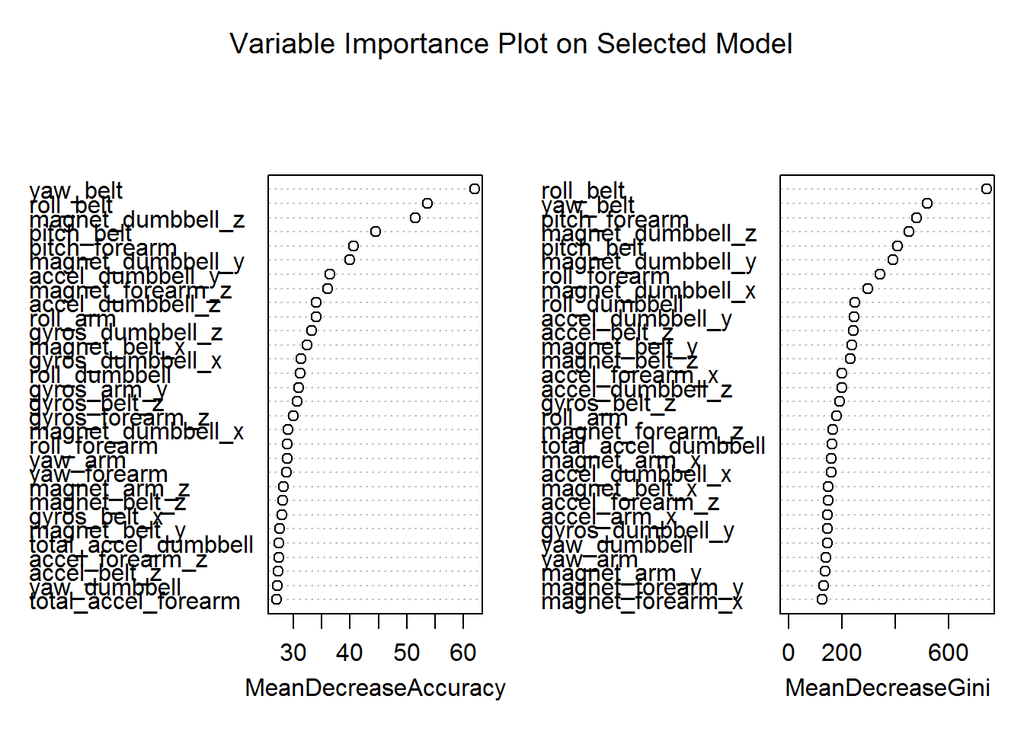

```r
varImpPlot(selectedModel,main="Variable Importance Plot on Selected Model")
```

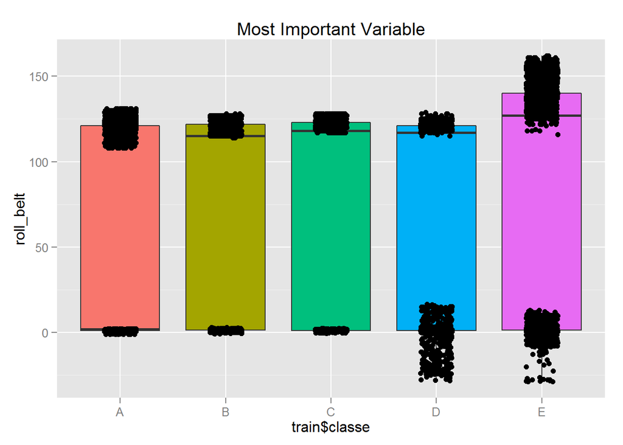

```r
ggplot(predictors_train, aes(train$classe,predictors_train[,"roll_belt"],fill=train$classe)) +
        geom_boxplot() + geom_jitter(position = position_jitter(width = .15)) +
        ylab("roll_belt") + guides(fill=FALSE) + ggtitle("Most Important Variable")
```

```r
ddply(predictors_train, .(train$classe), summarise, median_roll_belt = median(roll_belt))
```

```
##   train$classe median_roll_belt
## 1            A            1.885
## 2            B          115.000
## 3            C          118.000
## 4            D          117.000
## 5            E          127.000
```

# Cross Validation

The selected model was cross-validated using the test data set. I used cross-fold validation with 20 observations for each fold in order to gauge the expected accuracy for the submission test cases of the same size.

```r
set.seed(32323)
numFolds = floor(dim(test)[1]/20)  # set the number of folds to get approximately 20 test cases
folds <- createFolds(y=test$classe,k=numFolds,list=TRUE,returnTrain=FALSE)

summary(sapply(folds,length)) # checks the length of the folds for cross-validation
```

```
##    Min. 1st Qu.  Median    Mean 3rd Qu.    Max.
##   17.00   19.00   20.00   20.02   21.00   22.00
```

```r
accuracy_stat <- rep(0,times=numFolds)
kappa_stat <- rep(0,times=numFolds)
for (i in (1:numFolds)){
        test_fold <- test[folds[[i]],]
        predictors_test_fold <- test_fold[,colnames(test) %in% var_names]
        dim(predictors_test_fold)
        prediction_test_fold <- predict(selectedModel,predictors_test_fold)
        cfm_test_rf <- confusionMatrix(test_fold$classe,prediction_test_fold)
        accuracy_stat[i] <- cfm_test_rf$overall[1]
        kappa_stat[i] <- cfm_test_rf$overall[2]
}
summary(accuracy_stat)
```

```
##    Min. 1st Qu.  Median    Mean 3rd Qu.    Max.
##   0.900   1.000   1.000   0.992   1.000   1.000
```

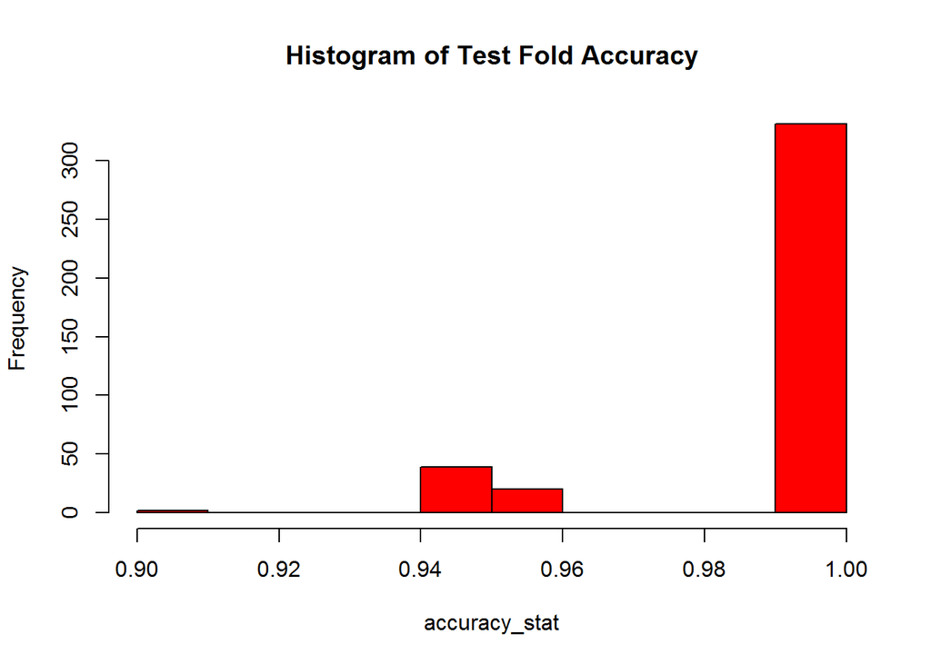

```r
hist(accuracy_stat,col="red", main="Histogram of Test Fold Accuracy")
```

```r
summary(kappa_stat)
```

```
##    Min. 1st Qu.  Median    Mean 3rd Qu.    Max.
##  0.8714  1.0000  1.0000  0.9898  1.0000  1.0000
```

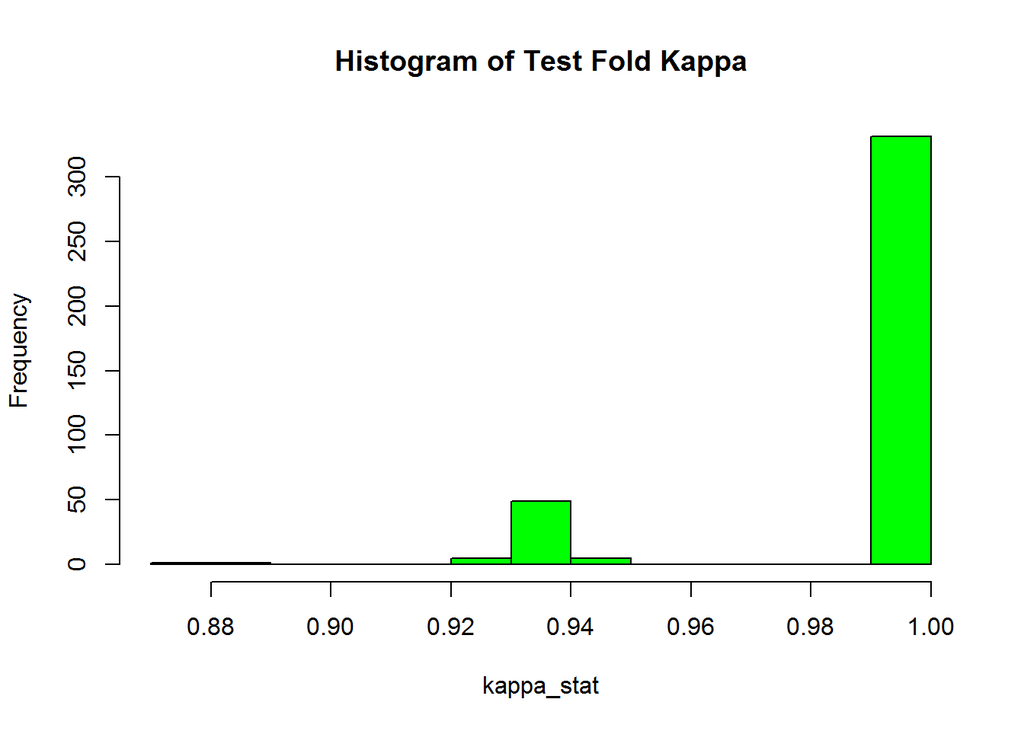

```r
hist(kappa_stat,col="green", main="Histogram of Test Fold Kappa")
```

# Final Results: To be Submitted on Testing Data Set

The predictions (or “answers”) for the submission data set, pml.testing.csv, are derived below for the selected model.

```r
dim(pml.testing)
```

```
## [1] 20 60
```

```r
predictors_pml.testing <- pml.testing[,colnames(pml.testing) %in% var_names]
dim(predictors_pml.testing)
```

```
## [1] 20 52
```

```r
answers <- predict(selectedModel,predictors_pml.testing)
answers <- as.character(answers)

answers
```

```
##  [1] "B" "A" "B" "A" "A" "E" "D" "B" "A" "A" "B" "C" "B" "A" "E" "E" "A"
## [18] "B" "B" "B"
```

```r
pml_write_files(answers)
```